# hello

Yufei xia

2019-02-05

## question 1

```r
help('scan')
data_frameA<-data.frame(name =c("john","lily"),character = c("male","female"), weight = c(72,65))
vectorB<-c(1,2,3,4)
write.table(data_frameA,"dataA")
write(vectorB,"vectorB")
read_A = read.table("dataA")
read_A
```

```
##   name character weight
## 1 john      male     72
## 2 lily    female     65
```

```r
data_frameA
```

```
##   name character weight
## 1 john      male     72
## 2 lily    female     65
```

```r
read_B = scan("vectorB")
read_B
```

```
## [1] 1 2 3 4
```

```r
vectorB
```

```
## [1] 1 2 3 4
```

```r
#after print we can easily see the contents in yhe files are same as in vector and data.frame
```

we get the same data.frame and same vector.

## question 2

```
## [1] TRUE
```

```
## [1] TRUE
```

```
## [1] 1 2 3 4 5
```

```
## [1]  6  7  8  9 10
```

```
## [1] 1 2 3 4 5 6 7
```

```
## [1]  7  8  9 10 11 12 13
```

Dump takes a vector of names of R objects and produces text representations of the objects on a file or connection,a dump file can usually be sourced into another R session. Save writes an external representation of R objects to the specified file,the objects can be read back from the file at a later date by using the function load or attach . so they are similar in both are present for R objects, the difference between them is that dump could be a source but save is doing rade back. after “dump” and “save” , if we remove the object we can get them back by source and load and it is same as the objects we created.

## question 3

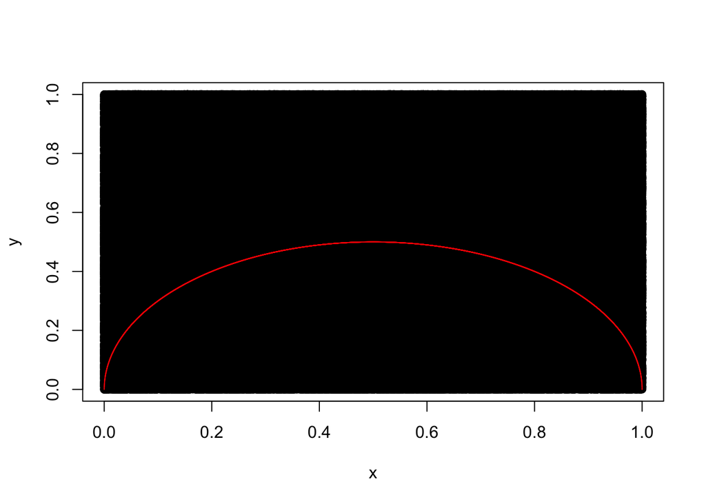

```r
## question 3
z =numeric()
x = runif(1000000)
y = runif(1000000)
plot(x,y)
lines(seq(0,1,by=0.000001),sqrt((1/2)^2-(seq(0,1,by=0.000001)-(1/2))^2),col=2)
```

```r
z=((x-(1/2))^2+(y-(1/2))^2<(1/2)^2)*4
pi.estimate=mean(z)
print("the pi estimate is")
```

```
## [1] "the pi estimate is"
```

```r
pi.estimate
```

```
## [1] 3.141336
```

```r
print("the varience is")
```

```
## [1] "the varience is"
```

```r
var(z)
```

```
## [1] 2.697355
```

```r
print("the confidence interval is")
```

```
## [1] "the confidence interval is"
```

```r
confidenceinterval=c(pi.estimate+1.96*sqrt(var(z))/sqrt(1000000),pi.estimate-1.96*sqrt(var(z))/sqrt(1000000))
confidenceinterval
```

```
## [1] 3.144555 3.138117
```

## question 4

```r
#a
g300 = chickwts[chickwts$weight>300,]
g300
```

```
##    weight      feed
## 11    309   linseed
## 26    327   soybean
## 27    329   soybean
## 31    316   soybean
## 37    423 sunflower
## 38    340 sunflower
## 39    392 sunflower
## 40    339 sunflower
## 41    341 sunflower
## 43    320 sunflower
## 45    334 sunflower
## 46    322 sunflower
## 48    318 sunflower
## 49    325  meatmeal
## 51    303  meatmeal
## 52    315  meatmeal
## 53    380  meatmeal
## 58    344  meatmeal
## 60    368    casein
## 61    390    casein
## 62    379    casein
## 64    404    casein
## 65    318    casein
## 66    352    casein
## 67    359    casein
## 71    332    casein
```

```r
#b
linsed = chickwts[chickwts$feed=="linseed",]
linsed
```

```
##    weight    feed
## 11    309 linseed
## 12    229 linseed
## 13    181 linseed
## 14    141 linseed
## 15    260 linseed
## 16    203 linseed
## 17    148 linseed
## 18    169 linseed
## 19    213 linseed
## 20    257 linseed
## 21    244 linseed
## 22    271 linseed
```

```r
#c
mean(linsed$weight)
```

```
## [1] 218.75
```

```r
#d
nonlinsed = chickwts[chickwts$feed!="linseed",]
mean(nonlinsed$weight)
```

```
## [1] 269.9661
```

## question 5

```r
library(MASS)
#combine
Pima=rbind(Pima.tr,Pima.te)
#check
p=all(rbind(Pima.tr,Pima.te)==Pima)
p
```

```
## [1] TRUE
```

```r
#seprate different standard
z=cut(Pima$bmi,c(0,15,16,18.5,25,30,35,40,Inf))
#label them
levels(z)=c("Very severely underweight","Severely underweight","Underweight","Normal","Overweight","Obese Class I","Obese Class II","Obese Class III")
table(z)
```

```
## z
## Very severely underweight      Severely underweight
##                         0                         0
##               Underweight                    Normal
##                         2                        62
##                Overweight             Obese Class I
##                       126                       158
##            Obese Class II           Obese Class III
##                       115                        69
```

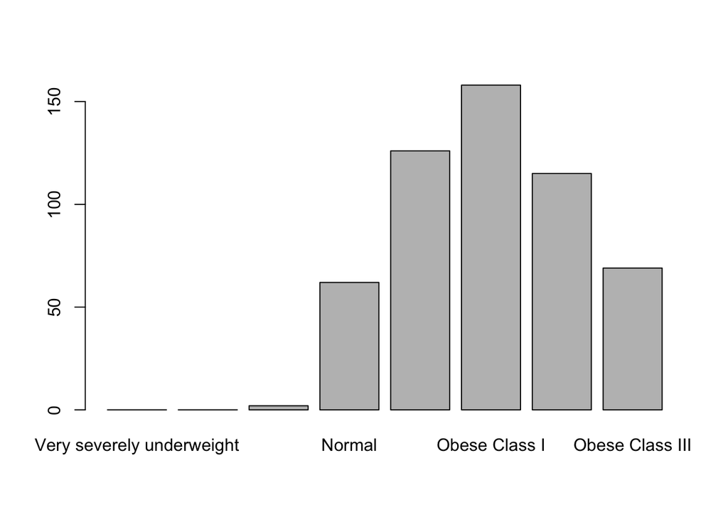

```r
plot(z)
```

```r
y=cut(Pima$bmi,c(0,18.5,25,Inf))
levels(y)=c("underweight","normal","overweight")
table(y)
```

```
## y
## underweight      normal  overweight
##           2          62         468
```

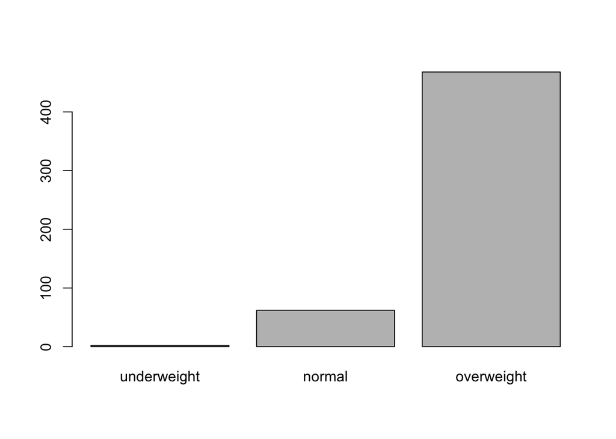

```r
plot(y)
```

#according to the barplot, it tells us only a few persons are underweight and the majority people are overweight, the number of normal weight persons are ok.

## question6

```r
#Question6
#a
#use lm function
h=lm(cars$dist~cars$speed,data=cars)
summary(h)
```

```
##
## Call:
## lm(formula = cars$dist ~ cars$speed, data = cars)
##
## Residuals:
##     Min      1Q  Median      3Q     Max
## -29.069  -9.525  -2.272   9.215  43.201
##
## Coefficients:
##             Estimate Std. Error t value Pr(>|t|)
## (Intercept) -17.5791     6.7584  -2.601   0.0123 *
## cars$speed    3.9324     0.4155   9.464 1.49e-12 ***
## ---
## Signif. codes:  0 '***' 0.001 '**' 0.01 '*' 0.05 '.' 0.1 ' ' 1
##
## Residual standard error: 15.38 on 48 degrees of freedom
## Multiple R-squared:  0.6511, Adjusted R-squared:  0.6438
## F-statistic: 89.57 on 1 and 48 DF,  p-value: 1.49e-12
```

```r
coefficient=coef(h)
#b
#use coefficient
D.hat=coefficient[1]+coefficient[2]*cars$speed
residuals=cars$dist-D.hat
residuals
```

```
##  [1]   3.849460  11.849460  -5.947766  12.052234   2.119825  -7.812584
##  [7]  -3.744993   4.255007  12.255007  -8.677401   2.322599 -15.609810
## [13]  -9.609810  -5.609810  -1.609810  -7.542219   0.457781   0.457781
## [19]  12.457781 -11.474628  -1.474628  22.525372  42.525372 -21.407036
## [25] -15.407036  12.592964 -13.339445  -5.339445 -17.271854  -9.271854
## [31]   0.728146 -11.204263   2.795737  22.795737  30.795737 -21.136672
## [37] -11.136672  10.863328 -29.069080 -13.069080  -9.069080  -5.069080
## [43]   2.930920  -2.933898 -18.866307  -6.798715  15.201285  16.201285
## [49]  43.201285   4.268876
```

```r
summary(residuals)
```

```
##    Min. 1st Qu.  Median    Mean 3rd Qu.    Max.
## -29.069  -9.525  -2.272   0.000   9.215  43.201
```

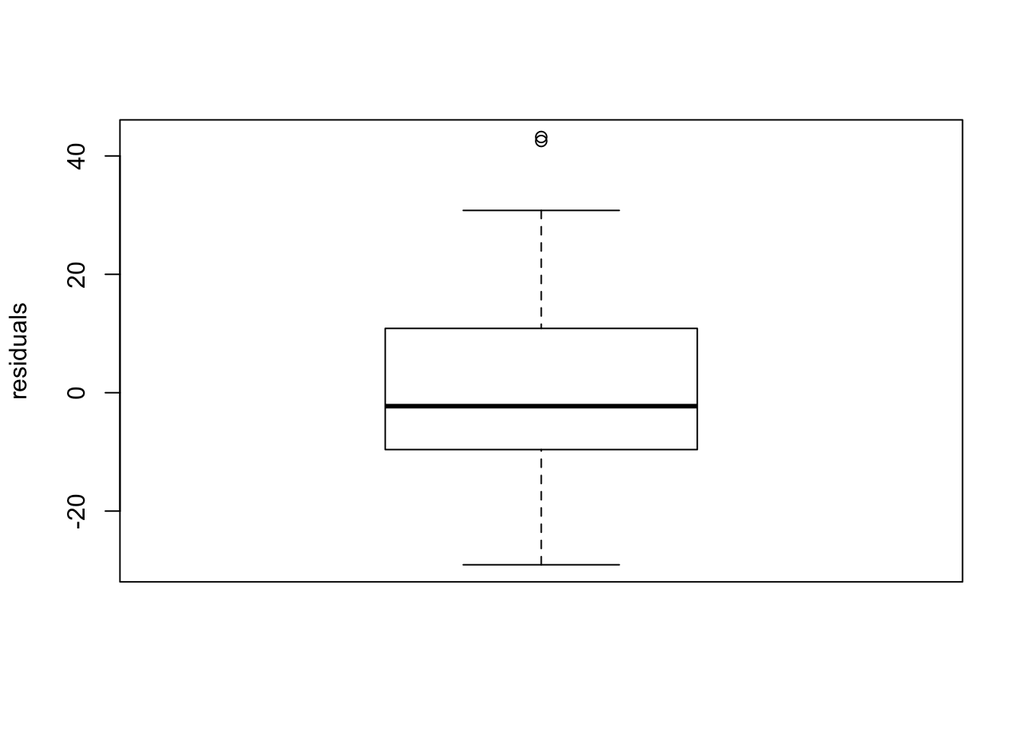

```r
#comment:it is same as the part a.
#c
#plot
boxplot(residuals,ylab="residuals")
```

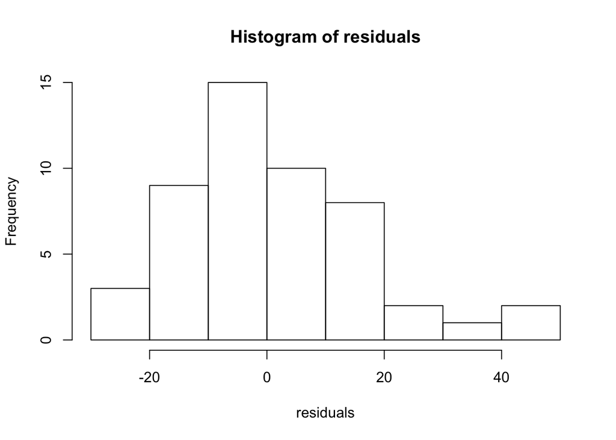

```r
#plot
hist(residuals)
```

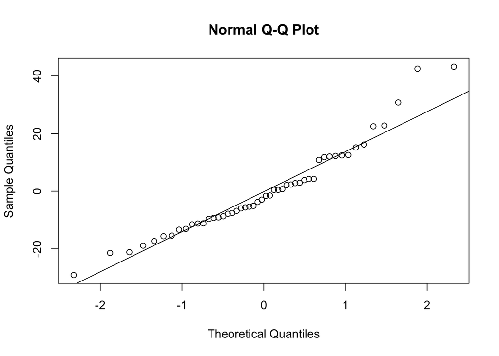

```r
#comment:histplot give us the good plot with group of distribution on variables,but boxplot give the most important line from the group.
#d
#plot qqnorm
qqnorm(residuals)
#plot qqline
qqline(residuals)
```

```r
#comment:qqline plot one exace line based on qqnorm.qqline can illustrate the approximate look of qqnorm.They are linearly dependent.
```